# Report 13

```r
df_outlier = df_complete[-influential_idx, ]

baseline_outlier = lm(diff_wis_season ~ pop_ratio + pct_urban +
    density_ratio + n_hsa + area_ratio + education_diff + income_diff +
    poverty_diff + unemployment_diff, data = df_outlier)
summary(baseline_outlier)
```

```
##
## Call:
## lm(formula = diff_wis_season ~ pop_ratio + pct_urban + density_ratio +
##     n_hsa + area_ratio + education_diff + income_diff + poverty_diff +
##     unemployment_diff, data = df_outlier)
##
## Residuals:
##      Min       1Q   Median       3Q      Max
## -0.49835 -0.11395 -0.00403  0.09041  0.92304
##
## Coefficients:
##                    Estimate Std. Error t value Pr(>|t|)
## (Intercept)       -0.049420   0.056362  -0.877  0.38194
## pop_ratio          0.109776   0.197191   0.557  0.57854
## pct_urban          0.097144   0.141249   0.688  0.49264
## density_ratio     -0.031797   0.010136  -3.137  0.00205 **
## n_hsa              0.010052   0.001454   6.911  1.2e-10 ***
## area_ratio         0.225172   0.371099   0.607  0.54490
## education_diff     1.926329   0.636441   3.027  0.00290 **
## income_diff        0.313903   0.231797   1.354  0.17765
## poverty_diff      -0.100772   1.226248  -0.082  0.93461
## unemployment_diff -3.206020   2.091851  -1.533  0.12742
## ---
## Signif. codes:  0 '***' 0.001 '**' 0.01 '*' 0.05 '.' 0.1 ' ' 1
##
## Residual standard error: 0.1848 on 154 degrees of freedom
## Multiple R-squared:  0.4104, Adjusted R-squared:  0.376
## F-statistic: 11.91 on 9 and 154 DF,  p-value: 3.853e-14
```

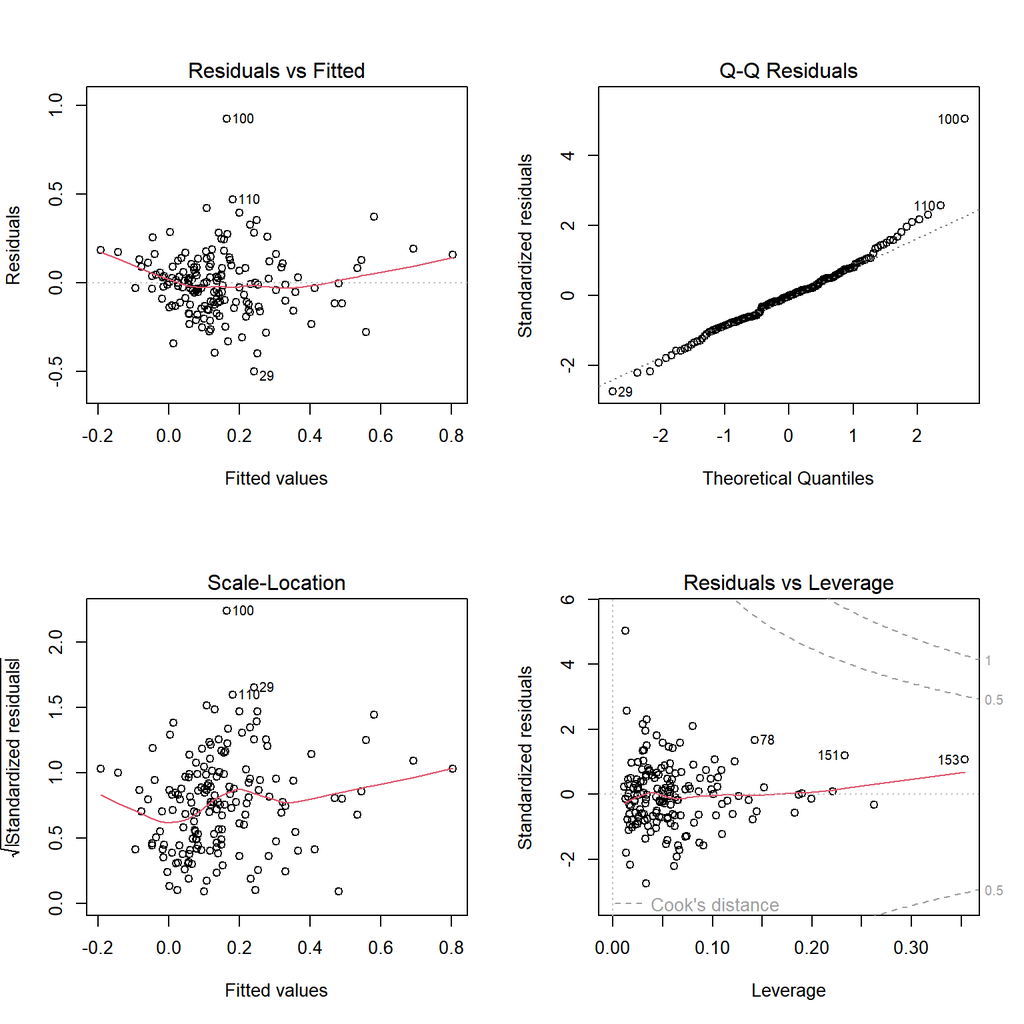

```r
par(mfrow = c(2, 2))
plot(baseline_outlier)
```

```r
par(mfrow = c(1, 1))
```

```r
pred_baseline_outlier = predict(baseline_outlier, newdata = df_outlier)
obs_outlier = df_outlier$diff_wis_season

R2_outlier = 1 - sum((obs_outlier - pred_baseline_outlier)^2)/sum((obs_outlier -
    mean(obs_outlier))^2)
RMSE_outlier = sqrt(mean((obs_outlier - pred_baseline_outlier)^2))
```

```r
K = 10
folds = sample(rep(1:K, length.out = nrow(df_outlier)))

cv_R2_values = c()

for (k in 1:K) {
    train_idx = which(folds != k)
    test_idx = which(folds == k)

    m = lm(diff_wis_season ~ pop_ratio + pct_urban + density_ratio +
        n_hsa + area_ratio + education_diff + income_diff + poverty_diff +
        unemployment_diff, data = df_outlier[train_idx, ])

    pred_k = predict(m, newdata = df_outlier[test_idx, ])
    obs_k = df_outlier$diff_wis_season[test_idx]

    R2_k = 1 - sum((obs_k - pred_k)^2)/sum((obs_k - mean(obs_k))^2)
    cv_R2_values[k] = R2_k
}

cv_mean_R2_outlier = mean(cv_R2_values)
```

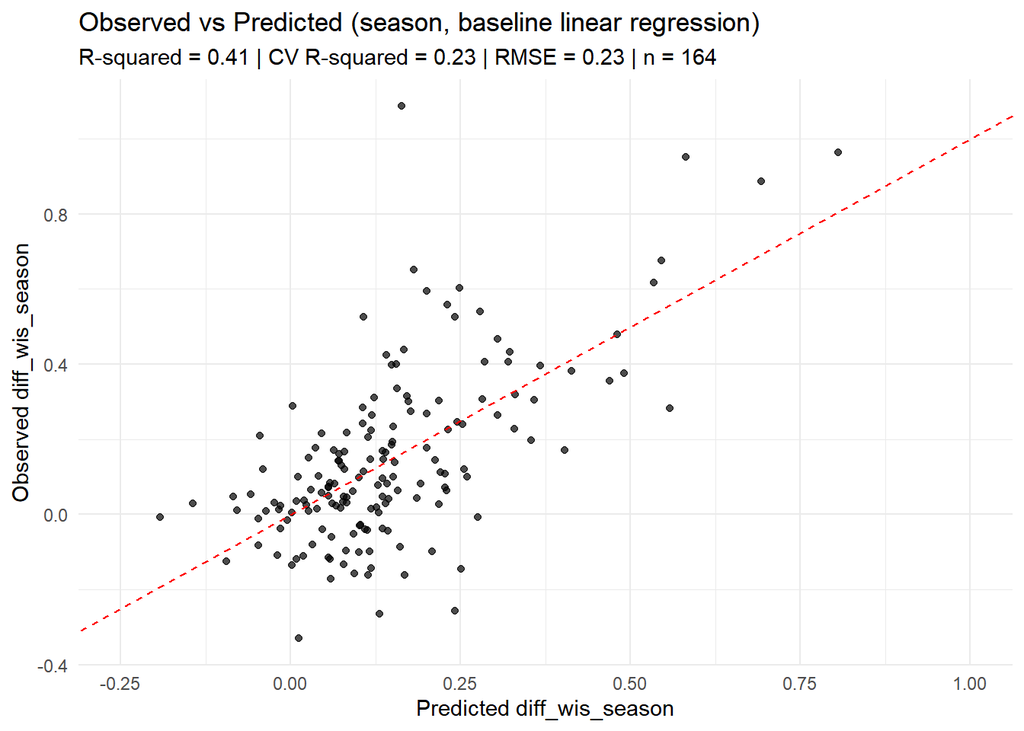

```r
baseline_predictions_outlier = data.frame(estimate = pred_baseline_outlier,
    observed = obs_outlier)

ggplot(baseline_predictions_outlier, aes(x = estimate, y = observed)) +
    geom_point(alpha = 0.7) + geom_abline(slope = 1, intercept = 0,
    linetype = "dashed", color = "red") + labs(x = "Predicted diff_wis_season",
    y = "Observed diff_wis_season", title = "Observed vs Predicted (season, baseline linear regression)",
    subtitle = sprintf("R-squared = %.2f | CV R-squared = %.2f | RMSE = %.2f | n = %.0f",
        R2_outlier, cv_mean_R2_outlier, RMSE, nrow(df_outlier))) +
    theme_minimal() + scale_x_continuous(breaks = seq(-1, 2,
    by = 0.25)) + coord_cartesian(xlim = c(-0.25, 1))
```

## Analysis

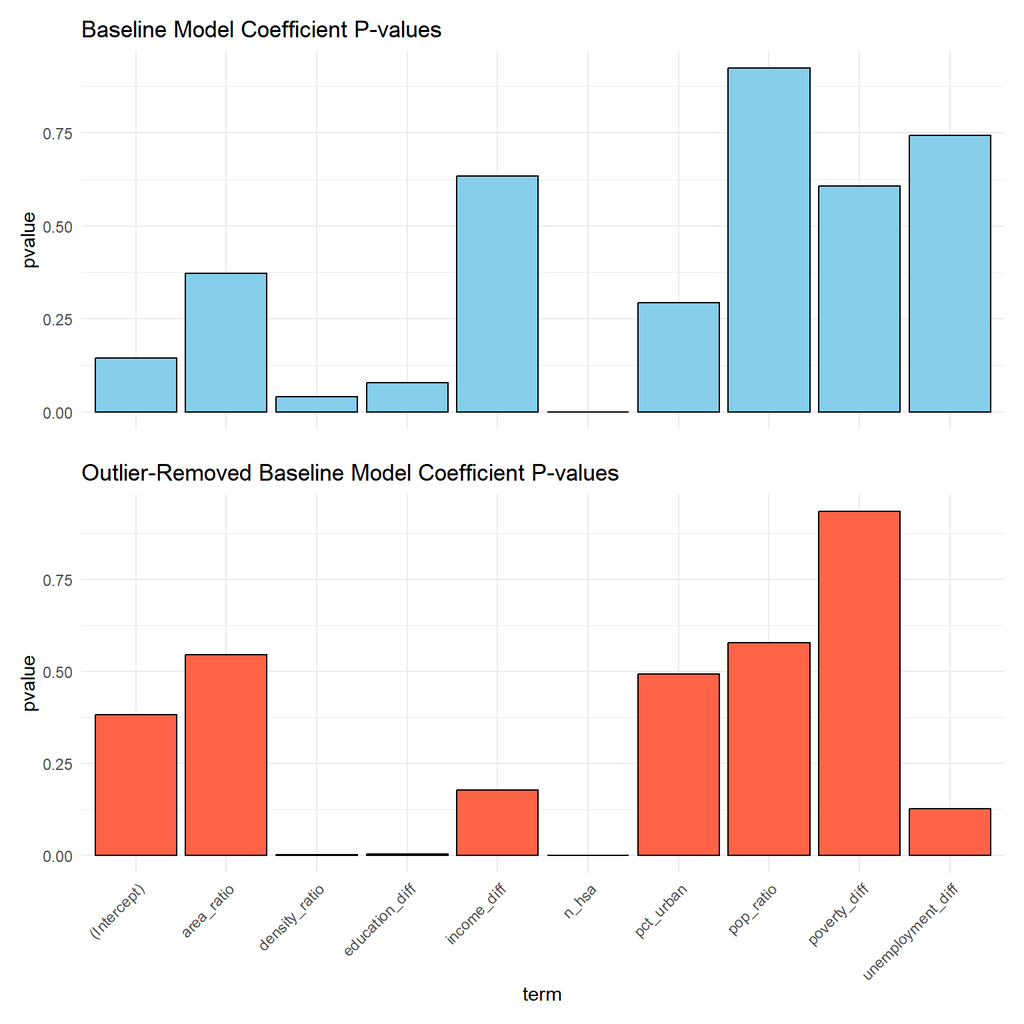

```r
pvals_baseline = summary(baseline)$coefficients[, "Pr(>|t|)"]
pvals_outlier = summary(baseline_outlier)$coefficients[, "Pr(>|t|)"]

b = ggplot(data.frame(term = names(pvals_baseline), pvalue = pvals_baseline),
    aes(x = term, y = pvalue)) + geom_col(fill = "skyblue", col = "black") +
    labs(title = "Baseline Model Coefficient P-values", x = element_blank()) +
    theme_minimal() + theme(axis.text.x = element_blank())

bo = ggplot(data.frame(term = names(pvals_outlier), pvalue = pvals_outlier),
    aes(x = term, y = pvalue)) + geom_col(fill = "tomato", col = "black") +
    labs(title = "Outlier-Removed Baseline Model Coefficient P-values") +
    theme_minimal() + theme(axis.text.x = element_text(angle = 45,
    hjust = 1))

b/bo
```

This baseline model mainly just serves to check how well the more complex models compare to a practically “naive” estimate of the difference between state and HSA. Both linear regression models (outlier and regular) both have n_hsa as the most important coefficient followed by density_ratio and then education_diff. While not identical, they maintain the ordering for the top three most significant coefficients. However, the outlier-removed model drops density_ratio and education_diff p-values into a very significant range at below 0.01.

These baseline models and outlier-removal will be useful in the upcoming sections to test against the XGBoost and BART models since they have solid RMSE and $R^2$ metrics. For reference, the outlier-removed model improves in every metric.

# Partial dependence plots

In this section, we want to look at more feature importance related questions regarding our two most complex models.

### BART

```r
bart_fit = bart(x.train = x.train, y.train = y.train, verbose = FALSE,
    keeptrees = TRUE)

pred_fun <- function(object, newdata) {
    preds <- predict(object, newdata = newdata)
    colMeans(preds)
}
```

First, let’s take a look at feature importance since it might be not the same as the baseline model.

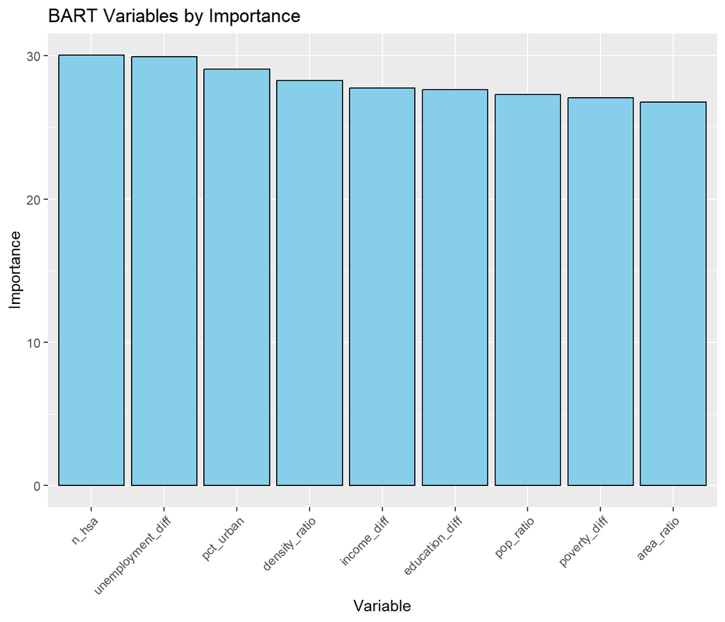

```r
bart_vi = as.data.frame(bart_fit$varcount) %>%
    summarise(across(everything(), ~mean(.x, na.rm = TRUE))) %>%
    pivot_longer(cols = everything(), names_to = "variable",
        values_to = "avg")


ggplot(bart_vi) + geom_col(aes(x = reorder(variable, -avg), y = avg),
    fill = "skyblue", col = "black") + labs(x = "Variable", y = "Importance",
    title = "BART Variables by Importance") + theme(axis.text.x = element_text(angle = 45,
    hjust = 1))
```

#### Regular

```r
hsa.pdp = pdp::partial(object = bart_fit, pred.var = "n_hsa",
    pred.fun = pred_fun, train = df_complete, plot = FALSE)
unemploy.pdp = pdp::partial(object = bart_fit, pred.var = "unemployment_diff",
    pred.fun = pred_fun, train = df_complete, plot = FALSE)
```

```r
hsa = ggplot(hsa.pdp, aes(n_hsa, yhat)) + geom_line(aes(group = yhat.id),
    alpha = 0.2) + stat_summary(fun = mean, geom = "line", col = "red",
    size = 1) + theme_minimal() + labs(title = "ICE plot for n_hsa",
    x = "n_hsa", y = "Predicted response") + scale_y_continuous(limits = c(-0.25,
    1.25), breaks = seq(-0.25, 1.25, by = 0.25))

unemploy = ggplot(unemploy.pdp, aes(unemployment_diff, yhat)) +
    geom_line(aes(group = yhat.id), alpha = 0.2) + stat_summary(fun = mean,
    geom = "line", col = "red", size = 1) + theme_minimal() +
    labs(title = "ICE plot for unemployment_diff", x = "unemployment_diff",
        y = "Predicted response") + scale_y_continuous(limits = c(-0.25,
    1.25), breaks = seq(-0.25, 1.25, by = 0.25))
```

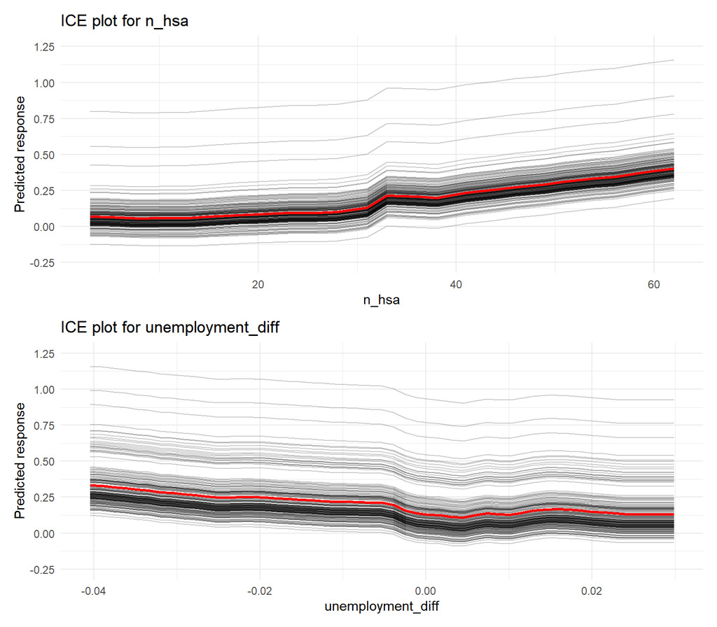

```r
hsa/unemploy
```

We can see that the different ICE lines have spread out along the “top” of these two figures while maintaining parallel to the PDP line and other ICE lines. That means that the effect might be changed drastically due to these outliers that maintain the global effect of these variables but skew the prediction.